# Simulating Generalised Linear Mixed Models

Author

James G. Hagan

# Simulation for GLM(M)s

How many times have you sat with your data, googling, asking ChatGPT, pulling hair out trying to figure out which model to fit for your experiment/study? If you’re like me, it’s been a lot of times. How many times have you sat there thinking: Does this model even do what I think it’s doing? Again, if you’re like me, there have been many times.

Now, what if I told you there was a way to solve these kinds of problems, improve reproducibility and your statistics skills? That solution is simulation and we love it here at DataWise.

## Example N: Biodiversity in food forests

I was present at a lively debate recently about the correct way to analyse an experiment that examined how the [*food-forest*](https://projectfoodforest.org/what-is-a-food-forest/) land-use type affects biodiversity. Specifically, the researchers were interested in whether food forests had more biodiversity value than other land-use types (e.g. agricultural fields). The experiment was designed in the following way. There were 30 locations throughout the Netherlands and Flanders (Belgium). At each of these 30 locations, there were two plots from the two groups i.e. food forest and agricultural field (there were actually four groups but, for simplicity, we will use two for this example). Within each of plots at each of the 30 locations (i.e. $30 * 2 = 60$ plots), ten samples were randomly taken. Therefore, within each of the two plots at a given location, 10 individual biodiversity measurements were taken (i.e. $30 * 2 * 10 = 600$ measurements). For this analysis, we will view the agricultural field group as the *control* and the food forest group as the *treatment* but this could also reasonably be switched around. In this specific case, it does not matter.

The resarcher proposed analysing these data using a linear mixed model (for simplicity, we will use a Gaussian error distribution but the same ideas apply to generalised linear models) with the following structure (where B - biodiversity, T - treatment and L - location) as represented in the classic tilde notation:

$$B \sim T + (1 | L)$$

But is this correct way to analyse these data? Let’s think very carefully about what this model is assuming. Before we do this, we will write the model equation. Do not worry about this model equation for now if you are not so inclined. However, I wrote it here because we will want to come back to all the different parameters in this model.

$$B_{i} \sim Normal(\mu_{i}, \sigma_{residual})$$
$$\mu_{i} = \alpha_{L[i]} + \beta_1(T_{i})$$
$$\alpha_{j} \sim Normal(\mu_{global}, \sigma_{global}) \text{, for location (L) j = 1,} \dots \text{,J}$$

So, what does this model assume? It assumes that the control plots (i.e. the agricultural fields) at all 30 locations ($j$) have some base-level of biodiversity ($\alpha_j$). These base-level biodiversity values ($\alpha_j$) are normally distributed with some global mean ($\mu_{global}$) and global standard deviation ($\sigma_{global}$). The model then assumes that the treatment has the same effect in all 30 locations (i.e. the difference between food forest and agricultural fields is the same across the 30 locations). Based on the base-level biodiversity values at the 30 locations ($\alpha_j$) and the treatment effect ($\beta_{1}$), the control (i.e. agricultural field) and treatment group (i.e. food forest) at each location have some mean value of biodiversity ($\mu_{i}$). The observed biodiversity values ($B_{i}$) are normally distributed around these mean values ($\mu_{i}$) for each location-group combination with some residual standard deviation ($\sigma_{residual}$).

Now we are going to simulate from this model and, I promise, this will become clearer. We went painfully through all the parameters in the model because the idea behind using simulation is to simulate these assumptions with specific parameter values, fit the model and then see if our model reproduces these parameter values. If the model cannot reproduce the parameters, then it means that our assumptions about how the model works are probably wrong.

We are going to do these simulations in [R](https://www.r-project.org) so feel free to follow along with the code. Before we start, we are going to load a few libraries that we will use for these simulations and the analysis.

```r
# function to check if a package is installed and then install it
install_if <- function(pkg) {
  if (!requireNamespace(pkg, quietly = TRUE)) {
    install.packages(pkg, dependencies = TRUE)
  }
  library(pkg, character.only = TRUE)
}

# load relevant libraries
install_if("lme4")
install_if("lmerTest")
install_if("ggplot2")
install_if("dplyr")
```

### Simulation 1

To start, we will specify the global mean ($\mu_{global}$) and the global standard deviation ($\sigma_{global}$) of the normal distribution that describes the base-level of biodiversity at each location in the control group (i.e. the agricultural field). Let’s visualise this:

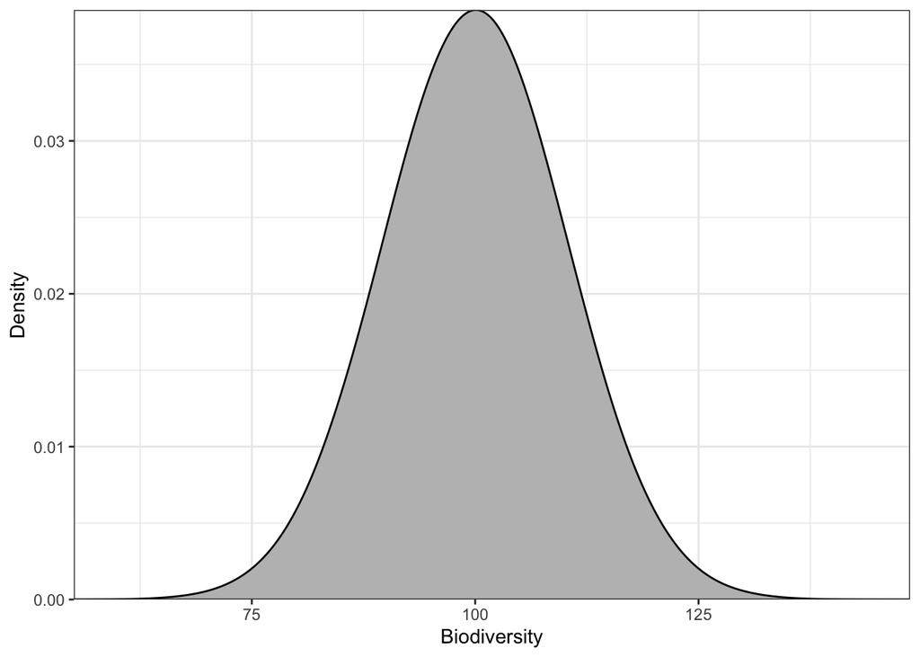

Figure 1: Base-level biodiversity at each location in the control group (i.e. the agricultural field).

```r
# set-up the global mean (mu_global = 100) and global standard deviation (sigma_global = 10)
mu_global <- 100
sigma_global <- 10

# sample from this distribution and plot the results
dist_global <- rnorm(n = 1000000, mean = mu_global, sd = sigma_global)

ggplot(mapping = aes(x = dist_global)) +
  geom_density(fill = "grey", bw = 2.5) +
  scale_x_continuous(expand = c(0, 0)) +
  scale_y_continuous(expand = c(0, 0)) +
  ylab("Density") +
  xlab("Biodiversity") +
  theme_bw()
```

In this experiment, we have 30 different locations. Therefore, we need to sample 30 times from this global distribution (i.e. Figure 1). These 30 samples are then the 30 base-level biodiversity values for the agricultural field plot (i.e. control plot) at each location ($\alpha_j$). We can visualise these 30 location mean values as red vertical lines on the global distribution (Figure 2):

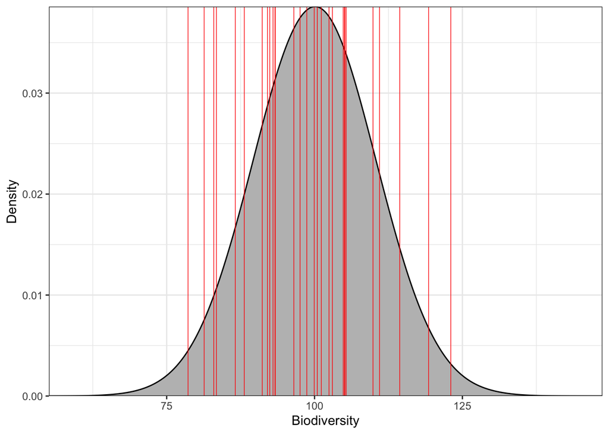

Figure 2: Samples (red, vertical lines) from the distribution of base-level biodiversity at each location in the control group (i.e. the agricultural field).

```r
# set the number of locations
locations <- 30

# take 15 random samples from the distribution
a_j <- rnorm(n = locations, mean = mu_global, sd = sigma_global)

ggplot() +
  geom_density(mapping = aes(x = dist_global),
               fill = "grey", bw = 2.5) +
  geom_vline(mapping = aes(xintercept = a_j), colour = "red", linewidth = 0.25) +
  scale_x_continuous(expand = c(0, 0)) +
  scale_y_continuous(expand = c(0, 0)) +
  ylab("Density") +
  xlab("Biodiversity") +
  theme_bw()
```

So, now we have our 30 base-level biodiversity values for agricultural fields at the 30 locations ($\alpha_j$) (Figure 2). Let’s visualise this in a different way that is more intuitive. Specifically, we plot each mean value on the y-axis and the x-axis simply indices the 30 locations. Moreover, we plot the global mean as a red, dashed, horizontal line.

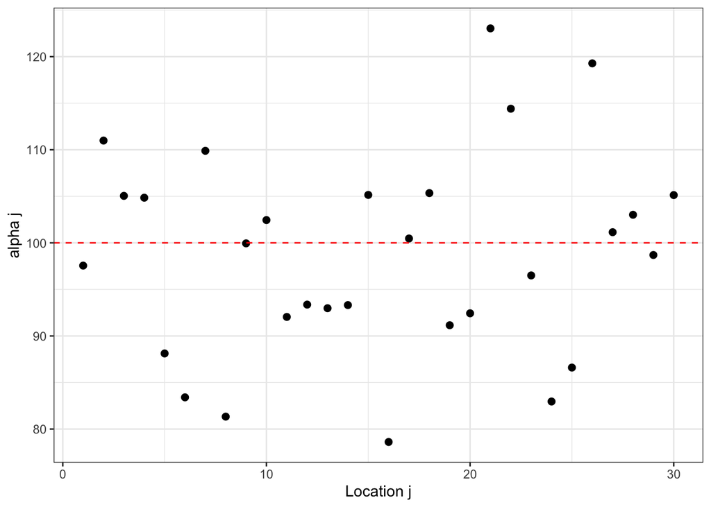

Figure 3: The base-level biodiversity values for the agricultural fields in the 30 sampled locations. The red, dashed horizontal line is the global mean of the distribution.

```r
# visualise the results as a location scatterplot
ggplot() +
  geom_point(mapping = aes(x = seq_along(a_j), y = a_j),
             colour = "black", size = 2) +
  geom_hline(yintercept = mu_global, colour = "red", linetype = "dashed") +
  ylab("alpha j") +
  xlab("Location j") +
  theme_bw()
```

The next thing that this model assumes is that the base-level biodiversity value in the control group (i.e. the agricultural field) is modified by the treatment (i.e. the food forest treatment group) ($\beta_1$). Moreover, in this specific model formulation, the treatment effect is assumed to be constant across all 30 locations.

We’ll assume a treatment effect of 5 (i.e. $\beta_1 = 5$). This means that, on average, biodiversity in food forests will be greater than in the agricultural fields by 5 units. We then add this treatment effect to all locations which gives us the mean biodiversity value at the 30 locations for the food forest (Figure 4).

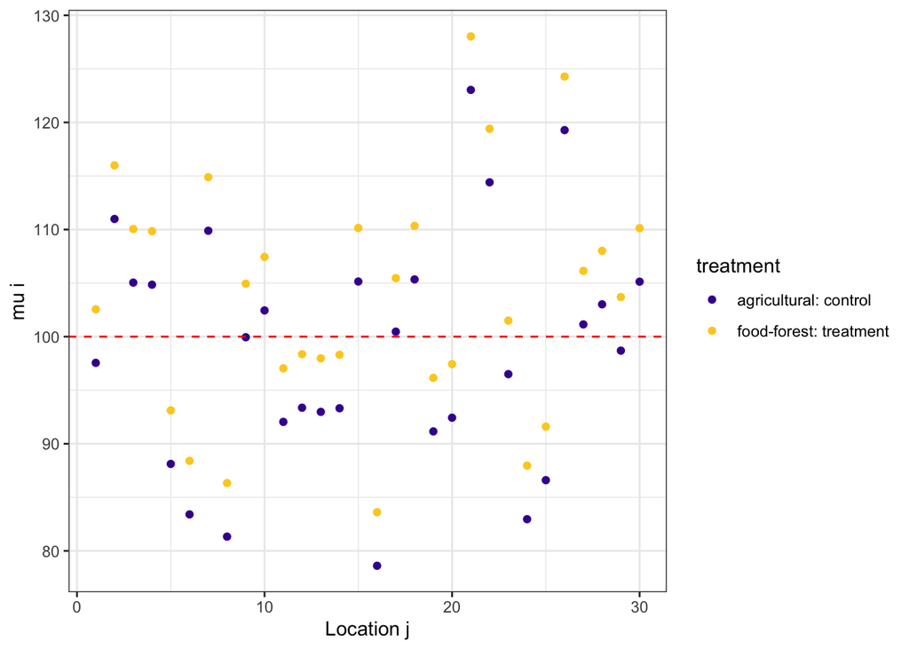

Figure 4: The base-level biodiversity values in the agricultural fields and the biodiversity values in the food forests in the 30 sampled locations.

```r
# set the treatment effect
b1 <- 5

# add the treatment effect
mu_i <- a_j + b1

# add the control plots to this vector
mu_i <- c(a_j, mu_i)

# pull into a data.frame
dat_mu <- dplyr::tibble(location = rep(c(seq_len(locations)), 2),
                        treatment = rep(c("agricultural: control", "food-forest: treatment"), each = locations),
                        mu_i = mu_i)

# visualise the results as a location scatterplot
ggplot(data = dat_mu,
       mapping = aes(x = location, y = mu_i, colour = treatment)) +
  geom_point() +
  geom_hline(yintercept = mu_global, colour = "red", linetype = "dashed") +
  scale_colour_viridis_d(option = "C", begin = 0.1, end = 0.9) +
  ylab("mu i") +
  xlab("Location j") +
  theme_bw()
```

So, now we have simulated the average biodiversity values in the control group (i.e. agricultural fields) and the average biodiversity values in the treatment group (i.e. food forests) as per the model (we hope) (Figure 4). The last thing we need to do is simulate the *observed biodiversity value* i.e. the 10 replicates in each plot in each location ($B_i$).

To do this, we assume that the biodiversity values ($B_i$) are normally distributed around the means ($\mu_{i}$) with some standard deviation ($\sigma_{residual}$) which we will set at 5:

```r
# number of within-plot replicates
replicates <- 10

# set the residual standard deviation
sigma_residual <- 5

# simulate six replicates in each location-group combination
dat_list <- vector("list", length = nrow(dat_mu))
for (i in seq_along(dat_list)) {

  # extract the first location-group combination
  x <- dat_mu[i, ]

  # simulate 6 random draws using the mean and residual standard deviation
  y <- rnorm(n = replicates, mean = x$mu_i, sd = sigma_residual)

  # add this to the data.frame
  z <- dplyr::tibble(location = x$location,
                     treatment = x$treatment,
                     B_i = y)

  # add this to an output list
  dat_list[[i]] <- z

}

# bind into a data.frame
dat <- dplyr::bind_rows(dat_list)
```

Now we have a fully simulated dataset which we can plot and which shows the simulated mean values as diamonds ($\mu_{i}$) and the simulated observed biodiversity values as circles ($B_i$).

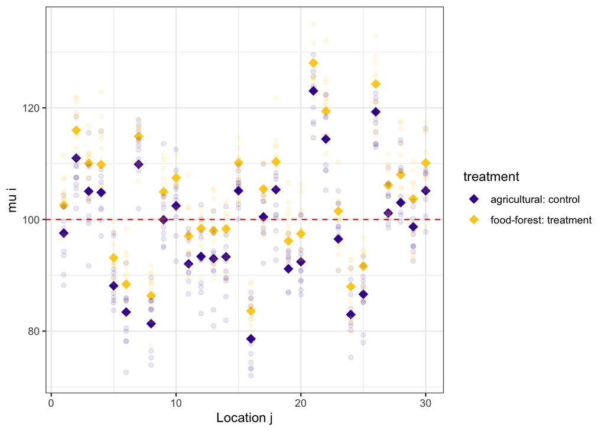

Figure 5: Simulated biodiversity values in the agricultural fields and in the food forests in the 30 sampled locations.

```r
# visualise the results as a location scatterplot
ggplot() +
  geom_point(data = dat_mu,
             mapping = aes(x = location, y = mu_i, colour = treatment),
             size = 3.5, shape = 18) +
  geom_point(data = dat,
             mapping = aes(x = location, y = B_i, colour = treatment),
             alpha = 0.1) +
  scale_colour_viridis_d(option = "C", begin = 0.1, end = 0.9) +
  geom_hline(yintercept = mu_global, colour = "red", linetype = "dashed") +
  ylab("mu i") +
  xlab("Location j") +
  theme_bw()
```

Using this simulated dataset, we can fit the linear mixed model using the [lme4 package](https://cran.r-project.org/web/packages/lme4/index.html) and see if we can reproduce the parameter values that we put into the model.

```r
# check the structure of the data
str(dat)
```

```
tibble [600 × 3] (S3: tbl_df/tbl/data.frame)
 $ location : int [1:600] 1 1 1 1 1 1 1 1 1 1 ...
 $ treatment: chr [1:600] "agricultural: control" "agricultural: control" "agricultural: control" "agricultural: control" ...
 $ B_i      : num [1:600] 90.1 102.2 102.4 97.1 104.3 ...
```

```r
# convert the location variable to a character
dat$location <- as.character(dat$location)

# fit the model
lmm1 <- lmerTest::lmer(B_i ~ treatment + (1 | location), data = dat)

# extract the summary
lmm1_sum <- summary(lmm1)

# print the summary
print(lmm1_sum)
```

```
Linear mixed model fit by REML. t-tests use Satterthwaite's method [
lmerModLmerTest]
Formula: B_i ~ treatment + (1 | location)
   Data: dat

REML criterion at convergence: 3731.7

Scaled residuals:
     Min       1Q   Median       3Q      Max
-2.59814 -0.70295  0.04854  0.67805  2.70039

Random effects:
 Groups   Name        Variance Std.Dev.
 location (Intercept) 113.39   10.648
 Residual              23.61    4.859
Number of obs: 600, groups:  location, 30

Fixed effects:
                                Estimate Std. Error       df t value Pr(>|t|)
(Intercept)                      98.6991     1.9642  29.6005   50.25   <2e-16
treatmentfood-forest: treatment   5.1969     0.3967 569.0000   13.10   <2e-16

(Intercept)                     ***
treatmentfood-forest: treatment ***
---
Signif. codes:  0 '***' 0.001 '**' 0.01 '*' 0.05 '.' 0.1 ' ' 1

Correlation of Fixed Effects:
            (Intr)
trtmntfd-:t -0.101
```

Now that we have fit the model, we can see if we can reproduce the parameters that we put into the model. Let’s start with the global mean ($\mu_{global}$) and global standard deviation ($\sigma_{global}$).

We set the global mean ($\mu_{global}$) to 100. Therefore, we should obtain a value close to 100 from our fitted model. To extract the mean, we need the intercept coefficient `(Intercept)` in this model. In this model, the estimated global mean (i.e. `(Intercept)`) was indeed very close to 100 (see below):

```r
# extract the global mean from the model: intercept term
print(paste0("Estimated global mean: ", lmm1_sum$coefficients[1,1]))
```

```
[1] "Estimated global mean: 98.6990697286247"
```

What about the global standard deviation ($\sigma_{global}$) which we set at 10? Indeed, the estimated global standard deviation is also very close to the 10 that we simulated:

```r
# extract the random effects
lmm1_re <- VarCorr(lmm1)

# the relevant standard deviation is the location standard deviation
x <- attr(lmm1_re$location, "stddev")
names(x) <- NULL

# extract the global mean from the model: intercept term
print(paste0("Estimated global standard deviation: ", x))
```

```
[1] "Estimated global standard deviation: 10.6482913317743"
```

What about the treatment effect ($B_1$)? We simulated a treatment effect of 5. Does the model reproduce this? Yes, it does.

```r
# extract the treatment effect from the model
print(paste0("Estimated treatment effect: ", lmm1_sum$coefficients[2,1]))
```

```
[1] "Estimated treatment effect: 5.19692350724794"
```

And, what about the residual variation which we set at 5? This also matches very well with our simulation:

```r
# extract the global mean from the model: intercept term
print(paste0("Estimated global standard deviation: ", lmm1_sum$sigma))
```

```
[1] "Estimated global standard deviation: 4.85870190455131"
```

Finally, the model estimates a mean value for each location ($\alpha_j$). We can also check if these mean values match with simulated the mean values for each site and again, the model reproduces these values very well (the red, dashed line is the 1:1 line) (Figure 6).

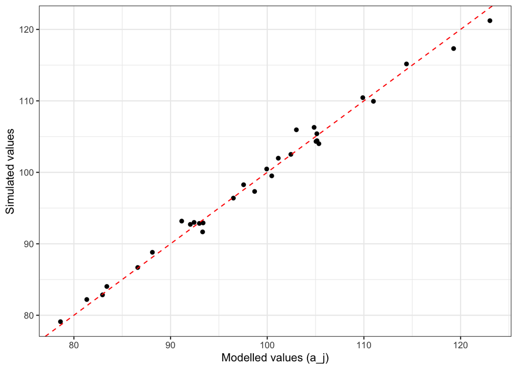

```r
# extract the model coefficients
lmm1_coef <- coef(lmm1)
lmm1_coef <- lmm1_coef$location

# get the rowname as a nummeric variable and sort
lmm1_coef$location <- as.numeric(row.names(lmm1_coef))
lmm1_coef <- dplyr::arrange(lmm1_coef, location)

# how do these values correlate with the simulated values
ggplot() +
  geom_point(mapping = aes(x = a_j, y = lmm1_coef$`(Intercept)`)) +
  geom_abline(intercept = 0, slope = 1, linetype = "dashed", colour = "red") +
  xlab("Modelled values (a_j)") +
  ylab("Simulated values") +
  theme_bw()
```

Hopefully, this exercise has convinced you that we understand the behaviour of the model because we were able to directly simulate it and the model reproduced all the simulated parameters with high levels of accuracy. Also, it is worth going back and increasing the replication in this simulation using the *locations* and *replicates* objects. If you increase these, the estimates should get better and better. But, now that we understand the assumptions and behaviour, we may ask ourselves are these assumptions reasonable?

### Simulation 2

In my view, the assumption that the treatment effect is the same across the different sites is problematic for this kind of study. No food forest is the same and no agricultural field is the same. Moreover, the locations cover a huge area with different environmental conditions which means that the biodiversity difference between a food forest and an agricultural field might be very different. By only fitting a single treatment effect parameter ($\beta_1$), the model is ignoring all of that variation and this can cause the significance of the effect to be inflated (Barr et al. 2013; Gelman and Brown 2024). Rather, what we need to do, is model the potential variation in treatment effects among the locations. By doing this, we will obtain the average treatment effect across all 30 locations by directly modelling variation among locations.

So what is different about this model compared to the previous model? Well, the only thing that differs is that we are now fitting a separate intercept and a separate treatment effect for each location rather than simply a separate intercept for each location ($\alpha_j$) and a single treatment effect ($\beta_1$) as we did in the first model. Moreover, we will assume that the intercepts and treatment effects are correlated. This just means that the model allows for the possibility that, for example, a high intercept is typically associated with a high (or low) treatment effect. As previously, I’m going to write the model equation out and then we will explore the assumptions of this model when we perform the simulation.

$$B_{i} \sim Normal(\mu_{i}, \sigma_{\text{residual}})$$
$$\mu_{i} = \alpha_{j} + \beta_{j}(\text{treatment}_{i})$$
$$\begin{pmatrix}
\alpha_{j} \\
\beta_{j}
\end{pmatrix}
\sim \mathcal{MVN} \left(
\begin{pmatrix}
\bar{\alpha} \\
\bar{\beta}
\end{pmatrix},
\begin{pmatrix}
\tau_{\alpha}^2 & \rho \tau_\alpha \tau_\beta \\
\rho \tau_\alpha \tau_\beta & \tau_{\beta}^2
\end{pmatrix}
\right), \text{for location (L) } j = 1, \dots, J$$

So, what does this model assume? It assumes that the control plots (i.e. the agricultural fields) at all locations ($j$) have some base-level of biodiversity ($\alpha_j$). This is the same as the previous model. The model then assumes that the treatment (i.e. the difference between the food forest and the agricultural fields) differs across the locations such that there is a separate treatment effect at each location ($\beta_{j}$). Therefore, based on the base-level biodiversity values at the locations ($\alpha_j$) and the treatment effects at the locations ($\beta_{j}$), the control (i.e. agricultural field) and treatment group (i.e. food forest) at each location have some mean value of biodiversity ($\mu_{i}$). Importantly, the $\alpha_j$ and $\beta_j$ values come from a common multivariate normal distribution. The observed biodiversity values ($B_{i}$) are normally distributed around these mean values ($\mu_{i}$) for each location-group combination with some residual standard deviation ($\sigma_{residual}$) as per the previous model.

How do we simulate this? To start with, we need to define the parameters of the multivariate normal distribution. As with the previous simulation, we will assume that the global mean across locations is 100 ($\bar{\alpha_j}$) and that the standard deviation is 10 (variance is 100), ($\tau_{\alpha}^2$). Next, we assume that average treatment effect is 5 ($\bar{\beta_j}$) and that the standard deviation is 3 (variance = 9) ($\tau_{\beta}^2$). Next, we assume that the $\alpha_j$ and $\beta_j$ values are correlated across locations with a correlation coefficient of 0.3 ($\rho$). Using these simulated values, we can draw pairs of $\alpha_j$ and $\beta_j$ values for each location from a multivariate normal distribution.

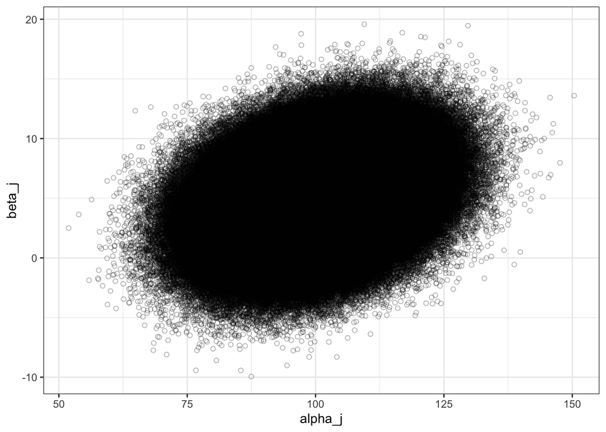

```r
# sim global mean (alpha_bar = 100) and variance (tau_alpha = 10)
alpha_bar <- 100
tau_alpha <- 10

# sim global treatment effect mean (beta_bar = 5) and standard deviation (tau_beta = 2.5)
beta_bar <- 5
tau_beta <- 3

# set the correlation coefficient
rho <- 0.3

# build the covariance matrix
cov_mat <- matrix(data = c((tau_alpha^2),
                           rho*tau_alpha*tau_beta,
                           rho*tau_alpha*tau_beta, (tau_beta^2)), 2, 2)

# simulate from the multivariate normal
dist_global <- MASS::mvrnorm(n = 1000000,
                             mu = c(alpha_bar, beta_bar),
                             Sigma = cov_mat)

# plot this multivariate normal distribution
dist_global <- dplyr::as_tibble(as.data.frame(dist_global))
names(dist_global) <- c("a_j", "b_j")

ggplot(data = dist_global,
       mapping = aes(x = a_j, y = b_j)) +
  geom_point(shape = 1, alpha = 0.3) +
  ylab("beta_j") +
  xlab("alpha_j") +
  theme_bw()
```

This figure shows 1000000 samples from the multivariate normal distribution that we set-up for $\alpha_j$ and $\beta_j$ (Figure 7). As you can see, their values are correlated such that information from $\alpha_j$ can provide information about $\beta_j$ (and *vice versa*). As this is the general distribution, we need to sample 30 locations from this which we overlay as red dots where each point represents both an $\alpha_j$ and $\beta_j$ for each location.

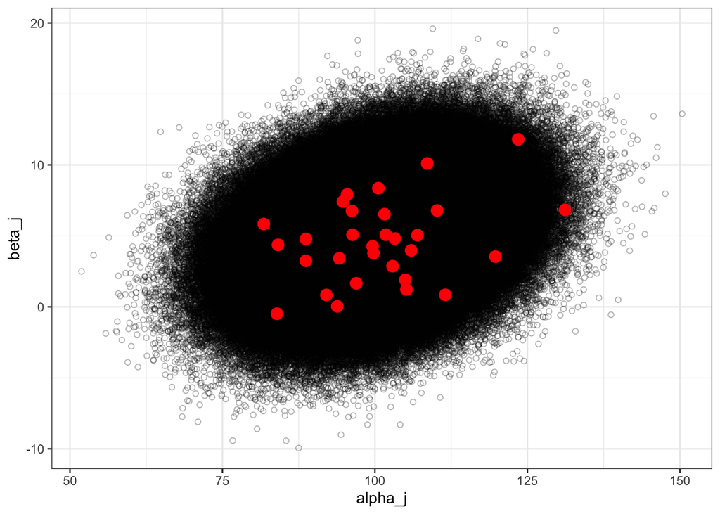

```r
# set the number of locations
locations <- 30

# simulate from the multivariate normal
dist_samp <- MASS::mvrnorm(n = locations,
                           mu = c(alpha_bar, beta_bar),
                           Sigma = cov_mat)

# plot this multivariate normal distribution
dist_samp <- dplyr::as_tibble(as.data.frame(dist_samp))
names(dist_samp) <- c("a_j", "b_j")

ggplot() +
  geom_point(data = dist_global,
       mapping = aes(x = a_j, y = b_j),
       shape = 1, alpha = 0.3) +
  geom_point(data = dist_samp,
             mapping = aes(x = a_j, y = b_j), colour = "red", size = 3.5) +
  ylab("beta_j") +
  xlab("alpha_j") +
  theme_bw()
```

Using these sampled values of $\alpha_j$ and $\beta_j$ (Figure 8), we can now build a dataset with the means of each control and treatment plot at each location ($\mu_{i}$). Let’s visualise this.

```r
# build a data.frame with the simulated means
dat_mu <-
  dplyr::tibble(location = rep(c(seq_len(locations)), 2),
                treatment = rep(c("agricultural: control", "food-forest: treatment"),
                                each = locations),
                mu_i = c(dist_samp$a_j, (dist_samp$a_j + dist_samp$b_j)))
head(dat_mu)
```

```
# A tibble: 6 × 3
  location treatment              mu_i
     <int> <chr>                 <dbl>
1        1 agricultural: control 105.
2        2 agricultural: control 101.
3        3 agricultural: control  84.1
4        4 agricultural: control 123.
5        5 agricultural: control  88.7
6        6 agricultural: control 107.
```

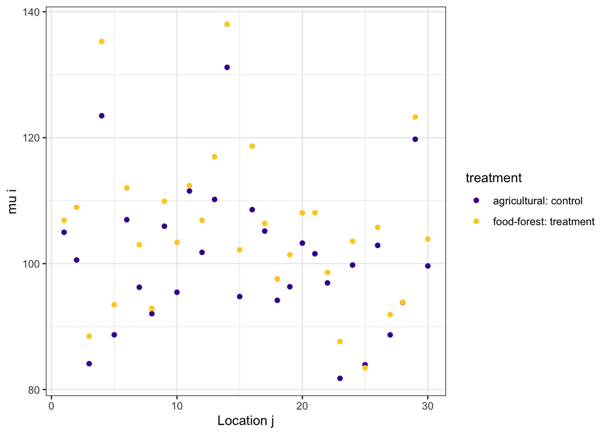

Figure 9: The base-level biodiversity values in the agricultural fields and the biodiversity values in the food forests in the 30 sampled locations.

```r
# visualise the results as a location scatterplot
ggplot(data = dat_mu,
       mapping = aes(x = location, y = mu_i, colour = treatment)) +
  geom_point() +
  scale_colour_viridis_d(option = "C", begin = 0.1, end = 0.9) +
  ylab("mu i") +
  xlab("Location j") +
  theme_bw()
```

As with the previous model, now that we have the simulated the average biodiversity values in the control group (i.e. agricultural fields) and the average biodiversity values in the treatment group (i.e. food forests) (Figure 9), the last thing we need to do is simulate the *observed biodiversity value* i.e. the 10 replicates in each plot in each location ($B_i$).

To do this, we assume that the biodiversity values ($B_i$) are normally distributed around the means ($\mu_{i}$) with some standard deviation ($\sigma_{residual}$) which we will set at 5:

```r
# number of within-plot replicates
replicates <- 10

# set the residual standard deviation
sigma_residual <- 5

# simulate six replicates in each location-group combination
dat_list <- vector("list", length = nrow(dat_mu))
for (i in seq_along(dat_list)) {

  # extract the first location-group combination
  x <- dat_mu[i, ]

  # simulate 6 random draws using the mean and residual standard deviation
  y <- rnorm(n = replicates, mean = x$mu_i, sd = sigma_residual)

  # add this to the data.frame
  z <- dplyr::tibble(location = x$location,
                     treatment = x$treatment,
                     B_i = y)

  # add this to an output list
  dat_list[[i]] <- z

}

# bind into a data.frame
dat <- dplyr::bind_rows(dat_list)
```

Now we have a fully simulated dataset which we can plot and which shows the simulated mean values as diamonds ($\mu_{i}$) and the simulated observed biodiversity values as circles ($B_i$) (Figure 10). As you can see, the difference between the biodiversity in food forests and agricultural fields differs between locations.

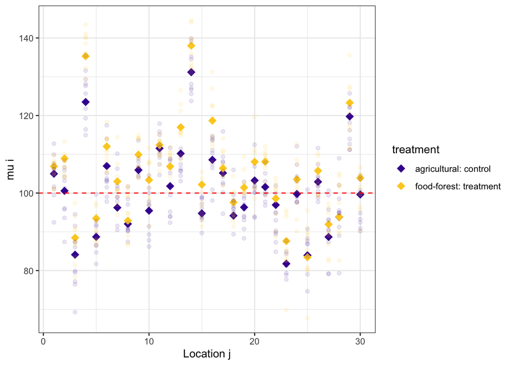

Figure 10: Simulated biodiversity values in the agricultural fields and in the food forests in the 30 sampled locations.

```r
#|
# visualise the results as a location scatterplot
ggplot() +
  geom_point(data = dat_mu,
             mapping = aes(x = location, y = mu_i, colour = treatment),
             size = 3.5, shape = 18) +
  geom_point(data = dat,
             mapping = aes(x = location, y = B_i, colour = treatment),
             alpha = 0.1) +
  scale_colour_viridis_d(option = "C", begin = 0.1, end = 0.9) +
  geom_hline(yintercept = mu_global, colour = "red", linetype = "dashed") +
  ylab("mu i") +
  xlab("Location j") +
  theme_bw()
```

Now, as with the first model, we can test whether the model that we fit was able to reproduce the parameters that we put into the model. So, let’s fit the model:

```r
# fit the model with correlated random intercepts and slopes
lmm2 <- lmerTest::lmer(B_i ~ treatment + (1 + treatment | location), data = dat)

# get the summary
lmm2_sum <- summary(lmm2)

# extract the variance-covariance values
lmm2_varcov <- VarCorr(lmm2)
lmm2_varcov <- lmm2_varcov$location

# print the summary
lmm2_sum
```

```
Linear mixed model fit by REML. t-tests use Satterthwaite's method [
lmerModLmerTest]
Formula: B_i ~ treatment + (1 + treatment | location)
   Data: dat

REML criterion at convergence: 3871.3

Scaled residuals:
    Min      1Q  Median      3Q     Max
-3.3692 -0.6133  0.0084  0.6460  2.8701

Random effects:
 Groups   Name                            Variance Std.Dev. Corr
 location (Intercept)                     117.579  10.843
          treatmentfood-forest: treatment   5.319   2.306   0.68
 Residual                                  29.355   5.418
Number of obs: 600, groups:  location, 30

Fixed effects:
                                Estimate Std. Error       df t value Pr(>|t|)
(Intercept)                     100.7699     2.0043  28.9999   50.28  < 2e-16
treatmentfood-forest: treatment   4.0368     0.6107  29.0000    6.61 3.04e-07

(Intercept)                     ***
treatmentfood-forest: treatment ***
---
Signif. codes:  0 '***' 0.001 '**' 0.01 '*' 0.05 '.' 0.1 ' ' 1

Correlation of Fixed Effects:
            (Intr)
trtmntfd-:t 0.384
```

Now, lets see if we can recover the parameters of the multivariate normal distribution that we simulated. We assumed that the global mean across locations was 100 ($\bar{\alpha_j}$) and that the standard deviation is 10 (variance is 100), ($\tau_{\alpha}^2$). The model was very close to both of these:

```r
# check the alpha_bar estimate from the model
print(paste0("Estimated global mean (alpha_bar): ", coefficients(lmm2_sum)[1, 1]))
```

```
[1] "Estimated global mean (alpha_bar): 100.769892005074"
```

```r
# check the alpha_bar estimate from the model
print(paste0("Estimated global sd (tau_alpha): ", attr(lmm2_varcov, "stddev")[1]))
```

```
[1] "Estimated global sd (tau_alpha): 10.8434055522121"
```

```r
# check the beta_bar estimate from the model
print(paste0("Estimated global mean effect (beta_bar): ", coefficients(lmm2_sum)[2, 1]))
```

```
[1] "Estimated global mean effect (beta_bar): 4.03678975873115"
```

```r
# check the alpha_bar estimate from the model
print(paste0("Estimated global sd (tau_beta): ", attr(lmm2_varcov, "stddev")[2]))
```

```
[1] "Estimated global sd (tau_beta): 2.30634156022958"
```

Moreover, we assumed that these two random variables ($\alpha_j$ and $\beta_j$) had a correlation of 0.30.

```r
# check the alpha_bar estimate from the model
print(paste0("Estimated correlation (rho): ", attr(lmm2_varcov, "correlation")[1, 2]))
```

```
[1] "Estimated correlation (rho): 0.681938322300404"
```

In addition, we set the residual standard deviation to 5 ($\sigma_{\text{residual}}$). This also matches very well with our model

```r
# extract the global mean from the model: intercept term
print(paste0("Estimated residual standard deviation: ", lmm2_sum$sigma))
```

```
[1] "Estimated residual standard deviation: 5.41803085895802"
```

Finally, the model estimates a mean value for each location ($\alpha_j$) and a treatment effect for each location ($\beta_j$). We can then see how well the model was able to reproduce these specific values. In general, the model does reasonably well although the treatment effects ($\beta_j$) could be better (Figure 11).

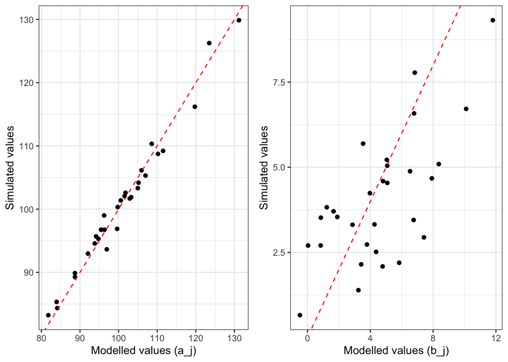

```r
# extract the model coefficients
lmm2_coef <- coef(lmm2)$location

# get the rowname as a nummeric variable and sort
lmm2_coef$location <- as.numeric(row.names(lmm2_coef))
lmm2_coef <- dplyr::arrange(lmm2_coef, location)

# how do these values correlate with the simulated values: a_j
p1 <-
  ggplot() +
  geom_point(mapping = aes(x = dist_samp$a_j, y = lmm2_coef[[1]])) +
  geom_abline(intercept = 0, slope = 1, linetype = "dashed", colour = "red") +
  xlab("Modelled values (a_j)") +
  ylab("Simulated values") +
  theme_bw()

# how do these values correlate with the simulated values: b_j
p2 <-
  ggplot() +
  geom_point(mapping = aes(x = dist_samp$b_j, y = lmm2_coef[[2]])) +
  geom_abline(intercept = 0, slope = 1, linetype = "dashed", colour = "red") +
  xlab("Modelled values (b_j)") +
  ylab("Simulated values") +
  theme_bw()

# combine and plot
cowplot::plot_grid(p1, p2, nrow = 1, ncol = 2)
```

So, now we have done the simulation again but with the more realistic assumption that the difference in biodiversity between food forests and agricultural fields can vary across locations. Moreover, we have shown that the fitted model could reproduce the simulated parameters. Again, if we were to increase our replication (i.e. *locations* and *replicates*), we should get closer and closer to the true simulated values.

## What was the point of these two simulations?

The reason we went through these two simulations was to help us think carefully about what we are assuming about the data-generating processes that produced our data when we fit different kinds of linear models. Specifically, I argued that, in this case, the assumption that the treatment effect (i.e. difference between food forests and agricultural fields in biodiversity) does not vary between locations is problematic and that, allowing the treatment effect to vary between locations is much more realistic. Now what I want to do is show you what would happen if our true data-generating process actually follows simulation 2 (i.e. treatment effect varies between locations) but we fit the model from simulation 1. I think this happens very frequently in ecological work.

So, what we are going to do is simulate the data based on **Simulation 2** (i.e. allowing the treatment effect to vary between locations). We are then going to fit both models and see what happens to our inference over many replicate simulations. To do this, I have wrapped the code for simulation 2 into a function that will allow us to do this. The code is very similar but is now more streamlined and allows one to easily run the simulation with different parameter values.

```r
# sim_lmm: fit lmm1 and lmm2 to simulated data
sim_lmm <- function(alpha_bar = 100, tau_alpha = 10, beta_bar = 5, tau_beta = 3,
                     rho = 0.5, locations = 30, replicates = 10, sigma_residual = 5) {

  # Load required libraries
  if (!requireNamespace("dplyr", quietly = TRUE)) stop("Package 'dplyr' is required.")
  if (!requireNamespace("lmerTest", quietly = TRUE)) stop("Package 'lmerTest' is required.")
  if (!requireNamespace("MASS", quietly = TRUE)) stop("Package 'MASS' is required.")

  # Build the covariance matrix
  cov_mat <- matrix(c(tau_alpha^2, rho * tau_alpha * tau_beta,
                      rho * tau_alpha * tau_beta, tau_beta^2),
                    nrow = 2, ncol = 2)

  # Simulate from the multivariate normal distribution
  dist_samp <- MASS::mvrnorm(n = locations, mu = c(alpha_bar, beta_bar), Sigma = cov_mat)

  # Convert to tibble and name columns
  dist_samp <- dplyr::as_tibble(as.data.frame(dist_samp))
  names(dist_samp) <- c("a_j", "b_j")

  # Build the data frame with simulated means
  dat_mu <-
    dplyr::tibble(
    location = rep(seq_len(locations), 2),
    treatment = rep(c("control", "treatment"), each = locations),
    mu_i = c(dist_samp$a_j, dist_samp$a_j + dist_samp$b_j)
  )

  # Simulate replicates for each location-treatment combination
  dat <-
    dat_mu |>
    dplyr::rowwise() |>
    dplyr::mutate(
      B_i = list(rnorm(n = replicates, mean = mu_i, sd = sigma_residual))
    ) |>
    dplyr::select(location, treatment, B_i) |>
    tidyr::unnest(cols = c(B_i))

  # Convert location variable to character
  dat$location <- as.character(dat$location)

  # Fit the linear mixed model with a random intercept only
  lmm1 <- lmerTest::lmer(B_i ~ treatment + (1 | location), data = dat)

  # Fit the linear mixed model with correlated random intercepts and slopes
  lmm2 <- lmerTest::lmer(B_i ~ treatment + (1 + treatment | location), data = dat)

  # Return the simulated data and the fitted model
  list(model1 = lmm1,
       model2 = lmm2)

}
```

So, let’s see how this function works. We will run a single replicate simulation (i.e. simulation 2 where treatment effects vary across locations) and fit both models (model1 and model2 respectively). This should convince you that the models are similar to what we have already done. Moreover, feel free to adjust some of the parameters and see what happens. For example, if you increase the number of locations (i.e. *locations*) and the number of replicates within each location (i.e. *replicates*), you should get estimates that are closer to the true, simulated parameter values.

```r
# run one replicate of the second simulation
sim2_obj <- sim_lmm(alpha_bar = 100, tau_alpha = 10, beta_bar = 5, tau_beta = 3,
                    rho = 0.3, locations = 30, replicates = 10, sigma_residual = 5)
summary(sim2_obj$model1)
```

```
Linear mixed model fit by REML. t-tests use Satterthwaite's method [
lmerModLmerTest]
Formula: B_i ~ treatment + (1 | location)
   Data: dat

REML criterion at convergence: 3841.6

Scaled residuals:
     Min       1Q   Median       3Q      Max
-3.02847 -0.67072  0.02646  0.66718  3.15265

Random effects:
 Groups   Name        Variance Std.Dev.
 location (Intercept) 93.98    9.694
 Residual             28.90    5.376
Number of obs: 600, groups:  location, 30

Fixed effects:
                   Estimate Std. Error       df t value Pr(>|t|)
(Intercept)         99.4647     1.7969  29.8846  55.353   <2e-16 ***
treatmenttreatment   4.2164     0.4389 569.0000   9.606   <2e-16 ***
---
Signif. codes:  0 '***' 0.001 '**' 0.01 '*' 0.05 '.' 0.1 ' ' 1

Correlation of Fixed Effects:
            (Intr)
trtmnttrtmn -0.122
```

```r
summary(sim2_obj$model2)
```

```
Linear mixed model fit by REML. t-tests use Satterthwaite's method [
lmerModLmerTest]
Formula: B_i ~ treatment + (1 + treatment | location)
   Data: dat

REML criterion at convergence: 3791.4

Scaled residuals:
     Min       1Q   Median       3Q      Max
-2.91836 -0.64251  0.01894  0.65236  2.94859

Random effects:
 Groups   Name               Variance Std.Dev. Corr
 location (Intercept)        72.18    8.496
          treatmenttreatment 14.24    3.774    0.57
 Residual                    25.27    5.027
Number of obs: 600, groups:  location, 30

Fixed effects:
                   Estimate Std. Error     df t value Pr(>|t|)
(Intercept)          99.465      1.578 29.000  63.031  < 2e-16 ***
treatmenttreatment    4.216      0.802 29.001   5.258 1.24e-05 ***
---
Signif. codes:  0 '***' 0.001 '**' 0.01 '*' 0.05 '.' 0.1 ' ' 1

Correlation of Fixed Effects:
            (Intr)
trtmnttrtmn 0.419
```

### Comparison of the two models

Now, let’s simulate 1000 replicates of simulation 2 and compare the resulting t-values for the treatment effect for models 1 and 2.

```r
# simulate 1000 replicates of simulation 2
sim_reps <- vector("list", length = 1000)
for (i in seq_along(sim_reps)) {

  # run one replicate of the second simulation (i.e. correlated random intercepts and slopes)
  sim_obj <- sim_lmm(alpha_bar = 100, tau_alpha = 10, beta_bar = 5, tau_beta = 3,
                     rho = 0.3, locations = 30, replicates = 10, sigma_residual = 5)

  # extract the model objects
  sim1_sum <- summary(sim_obj$model1)
  sim2_sum <- summary(sim_obj$model2)

  # extract the t-values for the treatment
  sim1_t <- coefficients(sim1_sum)[2, 4]
  sim2_t <- coefficients(sim2_sum)[2, 4]

  # extract the p-value for the treatment
  sim1_p <- coefficients(sim1_sum)[2, 5]
  sim2_p <- coefficients(sim2_sum)[2, 5]

  # bind into a data.frame
  sim_reps[[i]] <- dplyr::tibble(rep = i,
                                 sim = c(1, 2),
                                 t_val = c(sim1_t, sim2_t),
                                 p_val = c(sim1_p, sim2_p))

}

# bind into a data.frame
sim_rep_df <- dplyr::bind_rows(sim_reps)
```

Now, we can compare the t-values between the two models on the same simulated data where the treatment effect varied between locations. What we see is that the t-values are consistently higher in model 1 (Figure 12). This is because the model is ignoring the variation among locations. Model 2 is less certain about the treatment effect because it *knows* that there is variation. Indeed, the fact that the t-value for the treatment effect in model 1 is extremely high (on average 12) should raise some alarm bells.

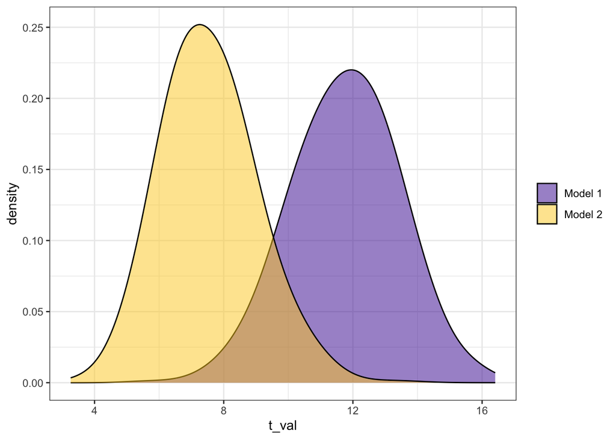

Figure 12: The difference between the t-values for the treatment effect in model 1 and model 2 when the data are simulated under the more realistic simulation 2 generating process.

```r
# compare the t-values between the two simulations
ggplot(data = sim_rep_df |> dplyr::mutate(sim = ifelse(sim == "1", "Model 1", "Model 2")),
       mapping = aes(x = t_val, fill = sim)) +
  geom_density(alpha = 0.5, bw = 0.7) +
  scale_fill_viridis_d(option = "C", begin = 0.1, end = 0.9) +
  theme_bw() +
  theme(legend.title = element_blank())
```

In my view, the only time when model 1 would be appropriate is if there is only one replicate per site in which case the experiment becomes a randomised block design. The model would then not be able to properly estimate the varying slope effects across locations. The other case is if there is no variation among locations in the treatment effect. Let’s do this by simply setting the slope variation to zero (`tau_beta = 0`). What happens in this case, is that the more complex model 2 becomes very similar to model 1. Moreover, the model will probably complain because of some numerical problems (e.g. boundary fit singular). This occurs because the model is trying to estimate the variation in beta but it is simply not there.

```r
sim_reps <- vector("list", length = 1000)
for (i in seq_along(sim_reps)) {

  # run one replicate of the second simulation (i.e. correlated random intercepts and slopes)
  sim_obj <- sim_lmm(alpha_bar = 100, tau_alpha = 10, beta_bar = 5, tau_beta = 0,
                     rho = 0, locations = 30, replicates = 10, sigma_residual = 5)

  # extract the model objects
  sim1_sum <- summary(sim_obj$model1)
  sim2_sum <- summary(sim_obj$model2)

  # extract the t-values for the treatment
  sim1_t <- coefficients(sim1_sum)[2, 4]
  sim2_t <- coefficients(sim2_sum)[2, 4]

  # extract the p-value for the treatment
  sim1_p <- coefficients(sim1_sum)[2, 5]
  sim2_p <- coefficients(sim2_sum)[2, 5]

  # bind into a data.frame
  sim_reps[[i]] <- dplyr::tibble(rep = i,
                                 sim = c(1, 2),
                                 t_val = c(sim1_t, sim2_t),
                                 p_val = c(sim1_p, sim2_p))

}

# bind into a data.frame
sim_rep_df <- dplyr::bind_rows(sim_reps)
```

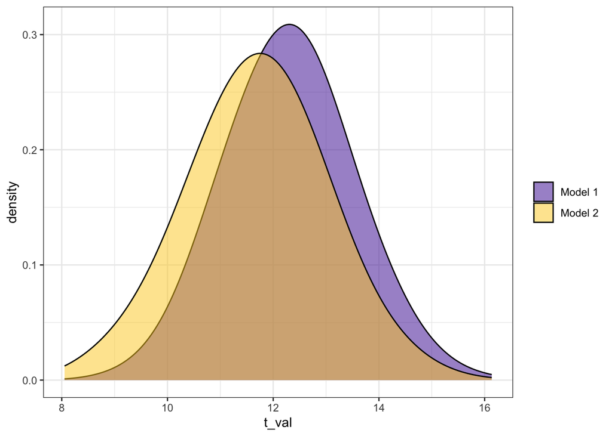

Figure 13: The difference between the t-values for the treatment effect in model 1 and model 2 when the data are simulated under the model 1 data-generating process with no variation among treatment effects.

```r
# compare the t-values between the two simulations
ggplot(data = sim_rep_df |> dplyr::mutate(sim = ifelse(sim == "1", "Model 1", "Model 2")),
       mapping = aes(x = t_val, fill = sim)) +
  geom_density(alpha = 0.5, bw = 0.7) +
  scale_fill_viridis_d(option = "C", begin = 0.1, end = 0.9) +
  theme_bw() +
  theme(legend.title = element_blank())
```

All of this is to say that, in this case, these simulations indicate that using model 2 is a more appropriate analysis. The only time that model 1 would become more appropriate is if there was only a single replicate per site or if there was very little variation in the treatment effect among locations. This is almost certainly not the case given this kind of field experiment. Moreover, even if this did turn out to be the case, it would still be better to try and model the variation in treatment effects and, only if the model was unable to fit, to use the simpler model.

This post was inspired by two great papers that helped me understand this varying intercept/varying slope distinction which are both well-worth reading. They are talking from a psychology perspective but similar problems apply to the ecological literature:

- Gelman and Brown (2024): http://www.stat.columbia.edu/~gelman/research/published/healing3.pdf
- Barr et al. (2013): https://www.sciencedirect.com/science/article/pii/S0749596X12001180

### Bonus round…

In this case, I made the simplifying assumption that the biodiversity variable was continuous and normally distributed. However, very few measures of biodiversity are actually like this… Take species richness, for example, this is probably more appropriate modelled as a Poisson random variable. We are now going to repeat Simulation 2 but using a Poisson generalised linear mixed model to show you what this looks like.

Like previously, we are going to write the equation. As you can, the model is very similar. The only difference is that the observed biodiversity ($B_{i}$) is Poisson distributed around some ($\lambda_{i}$). Moreover, the $\alpha_{j}$ and $\beta_{j}$ parameters determine the $log(\lambda_{i}$ value. This ensures that the $\lambda_{i}$ values are positive and that the linear model goes from negative infinity to positive infinity.

$$B_{i} \sim \text{Poisson}(\lambda_{i})$$
$$\log(\lambda_{i}) = \alpha_{j} + \beta_{j}(treatment_{i})$$
$$\begin{pmatrix}
\alpha_{j} \\
\beta_{j}
\end{pmatrix}
\sim \mathcal{MVN} \left(
\begin{pmatrix}
\bar{\alpha} \\
\bar{\beta}
\end{pmatrix}
,
\begin{pmatrix}
\tau_{\alpha}^2 & \rho \tau_\alpha \tau_\beta \\
\rho \tau_\alpha \tau_\beta & \tau_{\beta}^2
\end{pmatrix}
\right), \text{ for location } j = 1, \dots, J$$

Given the similarity in the equation, the simulation is very similar as well.

```r
# set the mean species richness value across locations
alpha_bar = log(100)

# set the variation in species richness across locations
tau_alpha = log(100)/10
print(tau_alpha)
```

```
[1] 0.460517
```

```r
# set the treatment effect
beta_bar = log(5)

# set the variation in the treatment effect
tau_beta = log(5)/2

# set the correlation between beta_j and alpha_j
rho = 0.5

# set the number of locations
locations = 1000

# set the number of replicates within each site (two sites per location)
replicates = 50

# Build the covariance matrix
cov_mat <- matrix(c(tau_alpha^2, rho * tau_alpha * tau_beta,
                  rho * tau_alpha * tau_beta, tau_beta^2),
                  nrow = 2, ncol = 2)

# Simulate from the multivariate normal distribution
dist_samp <- MASS::mvrnorm(n = locations, mu = c(alpha_bar, beta_bar), Sigma = cov_mat)

# Convert to tibble and name columns
dist_samp <- dplyr::as_tibble(as.data.frame(dist_samp))
names(dist_samp) <- c("a_j", "b_j")

# Build the data frame with simulated means
dat_mu <-
  dplyr::tibble(
  location = rep(seq_len(locations), 2),
  treatment = rep(c("control", "treatment"), each = locations),
  mu_i = c(dist_samp$a_j, dist_samp$a_j + dist_samp$b_j)
  )
```

But, things change when we have to simulated the observed biodiversity values. For this, we take the exponentiated $\mu_{i}$ value and pass it through the Poisson distribution to generate the observed biodiversity values ($B_{i}$).

```r
# Simulate species richness replicates for each location-treatment combination
dat <-
  dat_mu |>
  dplyr::rowwise() |>
  dplyr::mutate(
    B_i = list(rpois(n = replicates, lambda = exp(mu_i)))
    ) |>
  dplyr::select(location, treatment, B_i) |>
  tidyr::unnest(cols = c(B_i))

# Convert location variable to character
dat$location <- as.character(dat$location)

# Fit the linear mixed model with correlated random intercepts and slopes
glmm1 <- lme4::glmer(B_i ~ treatment + (1 + treatment | location),
                     family=poisson(link = log), data = dat)

# check the object
summary(glmm1)
```

```
Generalized linear mixed model fit by maximum likelihood (Laplace
  Approximation) [glmerMod]
 Family: poisson  ( log )
Formula: B_i ~ treatment + (1 + treatment | location)
   Data: dat

      AIC       BIC    logLik  deviance  df.resid
 841099.7  841147.3 -420544.9  841089.7     99995

Scaled residuals:
    Min      1Q  Median      3Q     Max
-4.2630 -0.6741 -0.0147  0.6551  4.2127

Random effects:
 Groups   Name               Variance Std.Dev. Corr
 location (Intercept)        0.2169   0.4658
          treatmenttreatment 0.6003   0.7748   0.51
Number of obs: 100000, groups:  location, 1000

Fixed effects:
                   Estimate Std. Error z value Pr(>|z|)
(Intercept)         4.60817    0.01474  312.73   <2e-16 ***
treatmenttreatment  1.61385    0.02451   65.84   <2e-16 ***
---
Signif. codes:  0 '***' 0.001 '**' 0.01 '*' 0.05 '.' 0.1 ' ' 1

Correlation of Fixed Effects:
            (Intr)
trtmnttrtmn 0.511
```